# FINAL_Political_Resistance_and_Participation_in_the_US

```python
# # if you do not have the folder to begin with:
#from google.colab import drive
#drive.mount('/content/drive')#,force_remount=True)
#%cd content/drive/MyDrive/MadBeignet.github.io.git
# !git clone git@github.com:MadBeignet/MadBeignet.github.io.git
# !git clone https://github.com/MadBeignet/MadBeignet.github.io
```

```python
#!ls
```

```python
#%cd../../../
```

```python
# # first, mount your google drive, change to the course folder, pull latest changes, and change to the lab folder.
#from google.colab import drive
#drive.mount('/content/drive',force_remount=True)
# %cd content/MadBeignet.github.io
# !git pull
%cd Data
```

```
[Errno 2] No such file or directory: 'Data'
/Users/maddiewisinski/Documents/GitHub/MadBeignet.github.io/Data
```

```python
!ls
```

```
PIRUS_May2020      Protests           archive_folder
Population         Voter_Turnouts     fancy_website.html
```

```python
#%cd "drive/MyDrive/MadBeignet.github.io/Data"
```

```python
# imports
import pandas as pd
import re
import seaborn as sns
import matplotlib.pyplot as plt
import sklearn
import numpy as np
from matplotlib.pyplot import figure
from sklearn.feature_extraction import DictVectorizer
from sklearn.preprocessing import StandardScaler
from sklearn.neighbors import KNeighborsRegressor
from sklearn.pipeline import Pipeline
from sklearn.model_selection import cross_val_score
from numpy.core.getlimits import inf
pd.set_option('mode.chained_assignment',None)
```

Team: Merrilee Montgomery and Maddie Wisinski

Website Link: https://madbeignet.github.io/

# Project Goals

The team will be looking at the relationship between political participation and political resistance in the United States from 2000-2021 by state.

To measure political participation, the team will use voter turnout statistics by state from collected by the Election Project. The election project website derives all its data from individual state websites.

This project will distinguish between violent and nonviolent political resistance. To measure nonviolent political resistance, this group will use protest frequency and size from Count Love, a group from MIT that began tracking protests amidst the 2017 Women's March. To study violent political resistance, this project will use Profiles of Individual Radicalization in the US (PIRUS) from University of Maryland National Consortium for the Study of Terrorism and Responses to Terrorism (START). The PIRUS Dataset contains informaiton about individuals who's radicalization became apparent through their plotting to engage in violent activity.

Election Project: https://www.electproject.org/home

Count Love: https://countlove.org/faq.html

PIRUS: https://www.start.umd.edu/data-tools/profiles-individual-radicalization-united-states-pirus

# Voter Turnout: 2000-2022

## Cleaning the Data

The Election Project collects voter turnout data for the general election that occur every two comes in separate CSVs by year. Here we want to read all by-year files into a single DataFrame. To do so, we must account for the following:

1. Years 2000-2010 are in a uniform format, but missing state abbreviation.
2. Years 2012-2020 have an extra column of state abreviation that can be used to create a index value consisting of Year and State Abbreviation.
3. Years 2016-2020 have notes at the end of each csv that must be deleted.

#### Step 1: Concatenate years 2000-2010

```python
csv_final = pd.read_csv("./Voter_Turnouts/2000 November General Election - Turnout Rates.csv",
                        header = None,
                        skiprows = 2)#first two rows is header in CSV
csv_final['Year']=2000

l = []#we will use this to make sure all files loaded
for a in range (2002,2012,2):
  csv_temp = pd.read_csv("./Voter_Turnouts/"+str(a)+" November General Election - Turnout Rates.csv",
                         header = None,
                         skiprows = 2)#first two rows are headers in csv
  csv_temp['Year']=a#As year is incremented,value changes
  l.append(1)
  csv_final = pd.concat([csv_final,csv_temp],ignore_index = True)
final_df = pd.DataFrame(csv_final)
print(len(l) == 5)#Test to make sure all files were uploaded, returns true if successful, false else
final_df.columns = ['Region', 'VEP Total Ballots Counted', 'VEP Highest Office', 'VAP Highest Office', 'Total Ballots Counted', 'Highest Office', 'Voting-Eligible Population (VEP)', 'Voting-Age Population (VAP)', '% Non-citizen', 'Prison', 'Probation', 'Parole', 'Total Ineligible Felon', 'Overseas Eligible', 'Year']
#Rename all columns

final_df
```

```
True
```

|  | Region | VEP Total Ballots Counted | VEP Highest Office | VAP Highest Office | Total Ballots Counted | Highest Office | Voting-Eligible Population (VEP) | Voting-Age Population (VAP) | % Non-citizen | Prison | Probation | Parole | Total Ineligible Felon | Overseas Eligible | Year |
| --- | --- | --- | --- | --- | --- | --- | --- | --- | --- | --- | --- | --- | --- | --- | --- |
| 0 | United States | 55.3% | 54.2% | 50.0% | 107,390,107 | 105,375,486 | 194,331,436 | 210,623,408 | 7.7% | 1,377,013 | 2,339,388 | 536,039 | 3,082,746 | 2,937,000 | 2000 |
| 1 | Alabama | NaN | 51.6% | 50.1% | NaN | 1,672,551 | 3,241,682 | 3,334,576 | 1.5% | 26,225 | 40,178 | 5,484 | 51,798 | NaN | 2000 |
| ... | ... | ... | ... | ... | ... | ... | ... | ... | ... | ... | ... | ... | ... | ... | ... |
| 310 | Wisconsin | 52.4% | 52.0% | 49.7% | 2,185,021 | 2,171,331 | 4,172,130 | 4,365,214 | 3.2% | 22,724 | 22,602 | 19,572 | 55,112 | NaN | 2010 |
| 311 | Wyoming | 46.0% | 45.5% | 43.8% | 190,822 | 188,463 | 414,536 | 430,673 | 2.4% | 2,059 | 3,231 | 682 | 5,684 | NaN | 2010 |

312 rows × 15 columns

#### Step 2: Drop State Abbreviations and Excess Rows

To concatenate Voter Turnout from years 2012-2022, we have to remove the abbreviation column and any excess rows (which are usually methodology notes.)

```python
l = []#we will use this to make sure all files loaded
for a in range (2012,2016,2):
  csv_temp = pd.read_csv("./Voter_Turnouts/"+str(a)+" November General Election - Turnout Rates.csv",
                         header = None,
                         skiprows = 2,
                         names = ['Region', 'VEP Total Ballots Counted', 'VEP Highest Office', 'VAP Highest Office', 'Total Ballots Counted', 'Highest Office', 'Voting-Eligible Population (VEP)', 'Voting-Age Population (VAP)', '% Non-citizen', 'Prison', 'Probation', 'Parole', 'Total Ineligible Felon', 'Overseas Eligible', 'State Abv'])#first two rows are headers in csv
  csv_temp['Year']=a#As year is incremented,value changes
  csv_temp = csv_temp.iloc[:52]
  csv_temp.drop('State Abv',inplace=True,axis=1)
  csv_final = pd.concat([csv_final,csv_temp],ignore_index=True)#not sure whats going wrong now, I'll ask Dr. Culotta

csv_final
```

|  | Region | VEP Total Ballots Counted | VEP Highest Office | VAP Highest Office | Total Ballots Counted | Highest Office | Voting-Eligible Population (VEP) | Voting-Age Population (VAP) | % Non-citizen | Prison | Probation | Parole | Total Ineligible Felon | Overseas Eligible | Year |
| --- | --- | --- | --- | --- | --- | --- | --- | --- | --- | --- | --- | --- | --- | --- | --- |
| 0 | United States | 55.3% | 54.2% | 50.0% | 107,390,107 | 105,375,486 | 194,331,436 | 210,623,408 | 7.7% | 1,377,013 | 2,339,388 | 536,039 | 3,082,746 | 2,937,000 | 2000 |
| 1 | Alabama | NaN | 51.6% | 50.1% | NaN | 1,672,551 | 3,241,682 | 3,334,576 | 1.5% | 26,225 | 40,178 | 5,484 | 51,798 | NaN | 2000 |
| ... | ... | ... | ... | ... | ... | ... | ... | ... | ... | ... | ... | ... | ... | ... | ... |
| 414 | Wisconsin | 56.9% | 56.6% | 53.9% | 2,422,248 | 2,410,314 | 4,260,427 | 4,454,970 | 3.1% | 22,097 | 46,212 | 20,010 | 67,986 | NaN | 2014 |
| 415 | Wyoming | 39.7% | 39.0% | 37.3% | 171,153 | 168,390 | 431,434 | 445,626 | 2.7% | 2,330 | 5,196 | 715 | 5,955 | NaN | 2014 |

416 rows × 15 columns

After 2014, Voter Turnout Data Column names and values vary more. As a result, we must clean each individual dataset to concatenate

#### 2018

```python
temp_18 = pd.read_csv("./Voter_Turnouts/2018 November General Election - Turnout Rates.csv",
                      names =['Region', 'Estimated or Actual 2018 Total Ballots Counted VEP Turnout Rate', '2018 Vote for Highest Office VEP Turnout Rate', 'Status', 'Source', 'Estimated or Actual 2018 Total Ballots Counted', '2018 Vote for Highest Office', 'Voting-Eligible Population (VEP)', 'Voting-Age Population (VAP)', '% Non-citizen', 'Prison', 'Probation', 'Parole', 'Total Ineligible Felon', 'Overseas Eligible', 'State Abv'],
                      skiprows=2,
                      header = None)
temp_18.drop('Source',inplace=True,axis=1)
temp_18.drop('Status',inplace=True,axis=1)
temp_18.drop('State Abv',inplace=True,axis=1)
csv_final.drop('VAP Highest Office',inplace=True,axis=1)
csv_final.columns
temp_18.columns = ['Region', 'VEP Total Ballots Counted', 'VEP Highest Office',
       'Total Ballots Counted', 'Highest Office',
       'Voting-Eligible Population (VEP)', 'Voting-Age Population (VAP)',
       '% Non-citizen', 'Prison', 'Probation', 'Parole',
       'Total Ineligible Felon', 'Overseas Eligible']
temp_18['Year']=2018
temp_18 = temp_18.iloc[:52]
csv_final = pd.concat([csv_final,temp_18],ignore_index = True)
csv_final
```

|  | Region | VEP Total Ballots Counted | VEP Highest Office | Total Ballots Counted | Highest Office | Voting-Eligible Population (VEP) | Voting-Age Population (VAP) | % Non-citizen | Prison | Probation | Parole | Total Ineligible Felon | Overseas Eligible | Year |
| --- | --- | --- | --- | --- | --- | --- | --- | --- | --- | --- | --- | --- | --- | --- |
| 0 | United States | 55.3% | 54.2% | 107,390,107 | 105,375,486 | 194,331,436 | 210,623,408 | 7.7% | 1,377,013 | 2,339,388 | 536,039 | 3,082,746 | 2,937,000 | 2000 |
| 1 | Alabama | NaN | 51.6% | NaN | 1,672,551 | 3,241,682 | 3,334,576 | 1.5% | 26,225 | 40,178 | 5,484 | 51,798 | NaN | 2000 |
| ... | ... | ... | ... | ... | ... | ... | ... | ... | ... | ... | ... | ... | ... | ... |
| 466 | Wisconsin | 61.4% | 61.4% | 2,675,000 | 2,673,308 | 4,354,527 | 4,563,564 | 3.1% | 22,889 | 44,489 | 20,401 | 68,649 | NaN | 2018 |
| 467 | Wyoming | 47.9% | 47.4% | 205,275 | 203,420 | 428,898 | 445,747 | 2.5% | 2,323 | 4,666 | 842 | 5,825 | NaN | 2018 |

468 rows × 14 columns

```python
l = 'Region,Source,Status,Total Ballots Counted (Estimate),Vote for Highest Office (President),VEP Turnout Rate (Total Ballots Counted),VEP Turnout Rate (Highest Office),Voting-Eligible Population (VEP),Voting-Age Population (VAP),% Non-citizen,Prison,Probation,Parole,Total Ineligible Felon,Overseas Eligible,State Abv'
lis = l.split(',')
print(lis)
```

```
['Region', 'Source', 'Status', 'Total Ballots Counted (Estimate)', 'Vote for Highest Office (President)', 'VEP Turnout Rate (Total Ballots Counted)', 'VEP Turnout Rate (Highest Office)', 'Voting-Eligible Population (VEP)', 'Voting-Age Population (VAP)', '% Non-citizen', 'Prison', 'Probation', 'Parol…
```

#### 2016

```python
temp_16 = pd.read_csv("./Voter_Turnouts/2016 November General Election - Turnout Rates.csv",
                      names =['Region', 'State Results Website', 'Status', 'VEP Total Ballots Counted', 'VEP Highest Office', 'VAP Highest Office', 'Total Ballots Counted (Estimate)', 'Highest Office', 'Voting-Eligible Population (VEP)', 'Voting-Age Population (VAP)', '% Non-citizen', 'Prison', 'Probation', 'Parole', 'Total Ineligible Felon', 'Overseas Eligible', 'State Abv'],
                      skiprows=2,
                      header = None)
temp_16.drop('Status',inplace=True,axis=1)
temp_16.drop('State Results Website',inplace=True,axis=1)
temp_16.drop('State Abv',inplace=True,axis=1)
temp_16.drop('VAP Highest Office',inplace=True,axis=1)
temp_16['Year']=2016
temp_16.columns = csv_final.columns
temp_16 = temp_16.iloc[:52]
csv_final = pd.concat([csv_final,temp_16],ignore_index = True)
csv_final
```

|  | Region | VEP Total Ballots Counted | VEP Highest Office | Total Ballots Counted | Highest Office | Voting-Eligible Population (VEP) | Voting-Age Population (VAP) | % Non-citizen | Prison | Probation | Parole | Total Ineligible Felon | Overseas Eligible | Year |
| --- | --- | --- | --- | --- | --- | --- | --- | --- | --- | --- | --- | --- | --- | --- |
| 0 | United States | 55.3% | 54.2% | 107,390,107 | 105,375,486 | 194,331,436 | 210,623,408 | 7.7% | 1,377,013 | 2,339,388 | 536,039 | 3,082,746 | 2,937,000 | 2000 |
| 1 | Alabama | NaN | 51.6% | NaN | 1,672,551 | 3,241,682 | 3,334,576 | 1.5% | 26,225 | 40,178 | 5,484 | 51,798 | NaN | 2000 |
| ... | ... | ... | ... | ... | ... | ... | ... | ... | ... | ... | ... | ... | ... | ... |
| 518 | Wisconsin | NaN | 69.5% | NaN | 2,976,150 | 4,285,071 | 4,495,783 | 3.2% | 22,889 | 44,489 | 20,401 | 68,649 | NaN | 2016 |
| 519 | Wyoming | 60.2% | 59.5% | 258,788 | 255,849 | 429,682 | 446,396 | 2.4% | 2,323 | 4,666 | 842 | 5,825 | NaN | 2016 |

520 rows × 14 columns

#### 2020

```python
temp_20 = pd.read_csv("./Voter_Turnouts/2020 November General Election - Turnout Rates.csv",
                      names =['Region', 'Source', 'Status', 'Total Ballots Counted (Estimate)', 'Vote for Highest Office (President)', 'VEP Turnout Rate (Total Ballots Counted)', 'VEP Turnout Rate (Highest Office)', 'Voting-Eligible Population (VEP)', 'Voting-Age Population (VAP)', '% Non-citizen', 'Prison', 'Probation', 'Parole', 'Total Ineligible Felon', 'Overseas Eligible', 'State Abv'],
                      skiprows=2,
                      header = None)
temp_20.drop('Source',inplace=True,axis=1)
temp_20.drop('Status',inplace=True,axis=1)
temp_20.drop('State Abv',inplace=True,axis=1)
temp_20 = temp_20[['Region','VEP Turnout Rate (Total Ballots Counted)','VEP Turnout Rate (Highest Office)','Total Ballots Counted (Estimate)', 'Vote for Highest Office (President)', 'Voting-Eligible Population (VEP)', 'Voting-Age Population (VAP)', '% Non-citizen', 'Prison', 'Probation', 'Parole', 'Total Ineligible Felon', 'Overseas Eligible']]
temp_20['Year'] = 2020
temp_20.columns = csv_final.columns
temp_20 = temp_20.iloc[:52]
csv_final = pd.concat([csv_final,temp_20],ignore_index = True)
csv_final
```

|  | Region | VEP Total Ballots Counted | VEP Highest Office | Total Ballots Counted | Highest Office | Voting-Eligible Population (VEP) | Voting-Age Population (VAP) | % Non-citizen | Prison | Probation | Parole | Total Ineligible Felon | Overseas Eligible | Year |
| --- | --- | --- | --- | --- | --- | --- | --- | --- | --- | --- | --- | --- | --- | --- |
| 0 | United States | 55.3% | 54.2% | 107,390,107 | 105,375,486 | 194,331,436 | 210,623,408 | 7.7% | 1,377,013 | 2,339,388 | 536,039 | 3,082,746 | 2,937,000 | 2000 |
| 1 | Alabama | NaN | 51.6% | NaN | 1,672,551 | 3,241,682 | 3,334,576 | 1.5% | 26,225 | 40,178 | 5,484 | 51,798 | NaN | 2000 |
| ... | ... | ... | ... | ... | ... | ... | ... | ... | ... | ... | ... | ... | ... | ... |
| 570 | Wisconsin | 75.8% | 75.5% | 3,310,000 | 3,298,041 | 4,368,530 | 4,586,746 | 3.2% | 23,574 | 42,909 | 21,015 | 71,193 | NaN | 2020 |
| 571 | Wyoming | 64.6% | 64.2% | 278,503 | 276,765 | 431,364 | 447,915 | 2.2% | 2,488 | 5,383 | 934 | 6,759 | NaN | 2020 |

572 rows × 14 columns

```python
states_cleaned = []
for e in csv_final.Region:
    e = str(e).replace('*','')
    states_cleaned.append(e)
csv_final.Region = states_cleaned

pd.unique(csv_final.Region)
```

```
array(['United States', 'Alabama', 'Alaska', 'Arizona', 'Arkansas',
       'California', 'Colorado', 'Connecticut', 'Delaware',
       'District of Columbia', 'Florida', 'Georgia', 'Hawaii', 'Idaho',
       'Illinois', 'Indiana', 'Iowa', 'Kansas', 'Kentucky', 'Louisiana',
       'Maine', 'Maryland', 'Massachusetts', 'Michigan', 'Minnesota',
       'Mississippi', 'Missouri', 'Montana', 'Nebraska', 'Nevada',
       'New Hampshire', 'New Jersey', 'New Mexico', 'New York',
       'North Carolina', 'North Dakota', 'Ohio', 'Oklahoma', 'Oregon',
       'Pennsylvania', 'Rhode Island', 'South Carolina', 'South Dakota',
       'Tennessee', 'Texas', 'Utah', 'Vermont', 'Virginia', 'Washington',
       'West Virginia', 'Wisconsin', 'Wyoming'], dtype=object)
```

## Radicalized Individuals in the United States

This data set is collected on the individual level. Because we are examining trends on the state level, we will save this Data grouped to the individuals' origin states.

#### 1. Loading the PIRUS Data

The PIRUS data measures 145 categorical and quantitative variables that do not load nicely into COLAB. We have taken the first header line from the CSV an split it into a list that can be passed as column names for the CSV.

```python
a = "Subject_ID,Loc_Plot_State1,Loc_Plot_City1,Loc_Plot_State2,Loc_Plot_City2,Date_Exposure,Plot_Target1,Plot_Target2,Plot_Target3,Attack_Preparation,Op_Security,Changing_Target,Anticp_Fatals_Targ,Internet_Use_Plot,Extent_Plot,Violent,Criminal_Severity,Criminal_Charges,Indict_Arrest,Current_Status,Group_Membership,Terrorist_Group_Name1,Terrorist_Group_Name2,Terrorist_Group_Name3,Actively_Recruited,Recruiter1,Recruiter2,Recruiter3,Actively_Connect,Group_Competition,Role_Group,Length_Group,Clique,Clique_Radicalize,Clique_Connect,Internet_Radicalization,Media_Radicalization,Social_Media,Social_Media_Frequency,Social_Media_Platform1,Social_Media_Platform2,Social_Media_Platform3,Social_Media_Platform4,Social_Media_Platform5,Social_Media_Activities1,Social_Media_Activities2,Social_Media_Activities3,Social_Media_Activities4,Social_Media_Activities5,Social_Media_Activities6,Social_Media_Activities7,Radicalization_Islamist,Radicalization_Far_Right,Radicalization_Far_Left,Radicalization_Single_Issue,Ideological_Sub_Category1,Ideological_Sub_Category2,Ideological_Sub_Category3,Loc_Habitation_State1,Loc_Habitation_City1,Loc_Habitation_State2,Loc_Habitation_City2,Itinerant,External_Rad,Rad_duration,Radical_Behaviors,Radical_Beliefs,US_Govt_Leader,Foreign_Govt_Leader,Event_Influence1,Event_Influence2,Event_Influence3,Event_Influence4,Beliefs_Trajectory,Behaviors_Trajectory,Radicalization_Sequence,Radicalization_Place,Prison_Radicalize,Broad_Ethnicity,Age,Marital_Status,Children,Age_Child,Gender,Religious_Background,Convert,Convert_Date,Reawakening,Reawakening_Date,Citizenship,Residency_Status,Nativity,Time_US_Months,Immigrant_Generation,Immigrant_Source,Language_English,Diaspora_Ties,Education,Student,Education_Change,Employment_Status,Change_Performance,Work_History,Military,Foreign_Military,Social_Stratum_Childhood,Social_Stratum_Adulthood,Aspirations,Abuse_Child,Abuse_Adult,Abuse_type1,Abuse_Type2,Abuse_Type3,Psychological,Alcohol_Drug,Absent_Parent,Overseas_Family,Close_Family,Family_Religiosity,Family_Ideology,Family_Ideological_Level,Prison_Family_Friend,Crime_Family_Friend,Radical_Friend,Radical_Family,Radical_Signif_Other,Relationship_Troubles,Platonic_Troubles,Unstructured_Time,Friendship_Source1,Friendship_Source2,Friendship_Source3,Kicked_Out,Previous_Criminal_Activity,Previous_Criminal_Activity_Type1,Previous_Criminal_Activity_Type2,Previous_Criminal_Activity_Type3,Previous_Criminal_Activity_Age,Gang,Gang_Age_Joined,Trauma,Other_Ideologies,Angry_US,Group_Grievance,Standing"
def listify(mis_string):
  return mis_string.split(",")
pirus_headlist = listify(a)
print(pirus_headlist)
```

```
['Subject_ID', 'Loc_Plot_State1', 'Loc_Plot_City1', 'Loc_Plot_State2', 'Loc_Plot_City2', 'Date_Exposure', 'Plot_Target1', 'Plot_Target2', 'Plot_Target3', 'Attack_Preparation', 'Op_Security', 'Changing_Target', 'Anticp_Fatals_Targ', 'Internet_Use_Plot', 'Extent_Plot', 'Violent', 'Criminal_Severity', …
```

```python
pirus_temp = pd.read_csv("./PIRUS_May2020/PIRUS_Public_May2020.csv",
                         header=1,
                         names = pirus_headlist)
pirus_temp
```

|  | Subject_ID | Loc_Plot_State1 | Loc_Plot_City1 | Loc_Plot_State2 | Loc_Plot_City2 | Date_Exposure | Plot_Target1 | Plot_Target2 | Plot_Target3 | Attack_Preparation | ... | Previous_Criminal_Activity_Type2 | Previous_Criminal_Activity_Type3 | Previous_Criminal_Activity_Age | Gang | Gang_Age_Joined | Trauma | Other_Ideologies | Angry_US | Group_Grievance | Standing |
| --- | --- | --- | --- | --- | --- | --- | --- | --- | --- | --- | --- | --- | --- | --- | --- | --- | --- | --- | --- | --- | --- |
| 0 | 4857 | New York | -99 | NaN | NaN | 1/1/49 | -88 | NaN | NaN | -88 | ... | NaN | NaN | -99 | 0 | -88 | 3 | 0 | 1 | -99 | -99 |
| 1 | 5803 | Alabama | Birmingham | NaN | NaN | 1/1/49 | -88 | NaN | NaN | -88 | ... | NaN | NaN | -88 | 0 | -88 | -99 | 0 | -99 | 2 | -99 |
| ... | ... | ... | ... | ... | ... | ... | ... | ... | ... | ... | ... | ... | ... | ... | ... | ... | ... | ... | ... | ... | ... |
| 2223 | 1374 | California | Los Angeles | NaN | NaN | 11/26/18 | 14 | NaN | NaN | 1 | ... | NaN | NaN | -99 | 0 | -88 | -99 | 0 | -99 | -99 | -99 |
| 2224 | 8295 | Ohio | Toledo | NaN | NaN | 12/10/18 | 3 | 14.0 | 15.0 | 2 | ... | NaN | NaN | 2 | 0 | -88 | -99 | 0 | 1 | 3 | -99 |

2225 rows × 145 columns

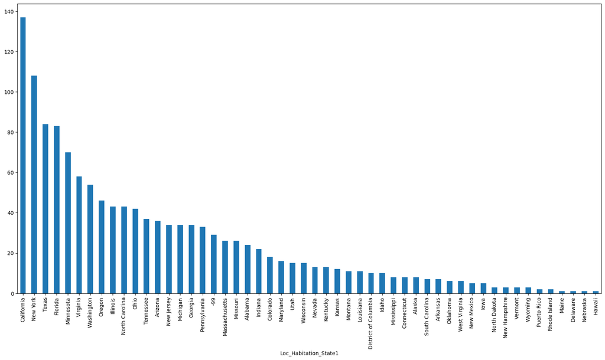

```python
#Date_Exposure is not comparable because it is of dtype string.
#Create column 'Year' of int values that represents the last 2 digit of the year.
l = []
for val in pirus_temp['Date_Exposure']:
  a = val.split('/')
  b = a[-1:]
  l.append(int(b[0]))
pirus_temp['Year'] = l
#Any row with 'Year' under 22 occured in the 2000's and is in the scope of this study
pirus_temp = pirus_temp[pirus_temp['Year'] <= 22]
#Group by state
pirus_states_since_2000 = pirus_temp.value_counts('Loc_Habitation_State1')
pirus_states_since_2000.plot(kind='bar', figsize=(20, 10))
```

## Protests in the United States

This data set is collected on the event level. Because we are examining trends on the state level, we will save this Data grouped to the protest event location. It is worth noting that popular protest often spreads. This data is harvested by webcrawling for news articles and similar media referencing the protest to a location. Therefore, protests that happened in wave, such as those in response to George Floyd's murder, will appearch multiple times. However, we will still count these as separate events, even if such events are comorbid.

Because this data set only covers 4 years, we do not have to filter it. We will only group it by state.

```python
protests_temp = pd.read_csv("./Protests/data.csv",
                         header = 1,
                         names = ['Date','Location','Attendees',
                         'Event (legacy; see tags)','Tags',
                         'Curated','Source','Total_Articles'])
protests_temp.head(20)
```

|  | Date | Location | Attendees | Event (legacy; see tags) | Tags | Curated | Source | Total_Articles |
| --- | --- | --- | --- | --- | --- | --- | --- | --- |
| 0 | 2017-01-16 | Johnson City, TN | 300.0 | Civil Rights | Civil Rights; For racial justice; Martin Luthe... | Yes | http://www.johnsoncitypress.com/Local/2017/01/... | 4 |
| 1 | 2017-01-16 | Indianapolis, IN | 20.0 | Environment | Environment; For wilderness preservation | Yes | http://wishtv.com/2017/01/16/nature-groups-pro... | 1 |
| ... | ... | ... | ... | ... | ... | ... | ... | ... |
| 18 | 2017-01-20 | Richmond, VA | 2000.0 | Executive (Inauguration March) | Executive; Against 45th president | Yes | http://richmondfreepress.com/news/2017/jan/20/... | 2 |
| 19 | 2017-01-20 | Madison, WI | 100.0 | Executive | Executive; Against 45th president | Yes | http://www.channel3000.com/news/politics/peace... | 1 |

20 rows × 8 columns

```python
#Must create state attribute to groupby state, similar to extracting year, but first create dictionary matching statges to abbreviation.
states = ["Alabama","Alaska","Arizona","Arkansas","California","Colorado","Connecticut","District of Columbia","Delaware","Florida","Georgia","Guam","Hawaii","Idaho","Illinois","Indiana","Iowa","Kansas","Kentucky","Louisiana","Maine","Maryland","Massachusetts","Michigan","Minnesota","Mississippi","Missouri","Montana","Nebraska","Nevada","New Hampshire","New Jersey","New Mexico","New York","North Carolina","North Dakota","Ohio","Oklahoma","Oregon","Pennsylvania","Puerto Rico","Rhode Island","South Carolina","South Dakota","Tennessee","Texas","United States","Utah", "Vermont","Virginia","Washington","West Virginia","Wisconsin","Wyoming"]
abbrev = ["AL","AK","AZ","AR","CA","CO","CT","DC","DE","FL","GA","GU","HI","ID","IL","IN","IA","KS","KY","LA","ME","MD","MA","MI","MN","MS","MO","MT","NE","NV","NH","NJ","NM","NY","NC","ND","OH","OK","OR","PA","PR","RI","SC","SD","TN","TX","US","UT","VT","VA","WA","WV","WI","WY"]
states_dict = {}
i = 0
for name in abbrev:
  states_dict[name] = states[i]
  i += 1
print(states_dict)
#create list of state names
protests_temp
```

```
{'AL': 'Alabama', 'AK': 'Alaska', 'AZ': 'Arizona', 'AR': 'Arkansas', 'CA': 'California', 'CO': 'Colorado', 'CT': 'Connecticut', 'DC': 'District of Columbia', 'DE': 'Delaware', 'FL': 'Florida', 'GA': 'Georgia', 'GU': 'Guam', 'HI': 'Hawaii', 'ID': 'Idaho', 'IL': 'Illinois', 'IN': 'Indiana', 'IA': 'Iow…
```

|  | Date | Location | Attendees | Event (legacy; see tags) | Tags | Curated | Source | Total_Articles |
| --- | --- | --- | --- | --- | --- | --- | --- | --- |
| 0 | 2017-01-16 | Johnson City, TN | 300.0 | Civil Rights | Civil Rights; For racial justice; Martin Luthe... | Yes | http://www.johnsoncitypress.com/Local/2017/01/... | 4 |
| 1 | 2017-01-16 | Indianapolis, IN | 20.0 | Environment | Environment; For wilderness preservation | Yes | http://wishtv.com/2017/01/16/nature-groups-pro... | 1 |
| ... | ... | ... | ... | ... | ... | ... | ... | ... |
| 38094 | 2021-01-31 | Salt Lake City, UT | NaN | Other | Other; Against deregulation; Business | No | https://www.abc4.com/news/local-news/crowds-ga... | 1 |
| 38095 | 2021-01-31 | San Francisco, CA | 100.0 | Other | Other; Against hazardous conditions; Prisons; ... | Yes | https://www.mercurynews.com/2021/01/31/activis... | 1 |

38096 rows × 8 columns

```python
#Create a list that can be added as a column to the DataFrame, representing the locatiion the protest took place in.
l = []
for val in protests_temp['Location']:
  m = val.split(',')
  if len(m) >= 2:
    n = m[-1][-2:]
    state = states_dict[n.upper()]
    l.append(state)
  else: #accounting for abnormal cases. implementation based on printing individual cases
    if m == 'La Porte County Courthouse in La Porte':
      l.append('Indiana')
    if m == 'Space':
      l.append('New York')
    if n == 'WA':
      l.append('Washington')
    if n == 'DE':
      l.append('Delaware')
protests_temp['State'] = l
#protests_temp
```

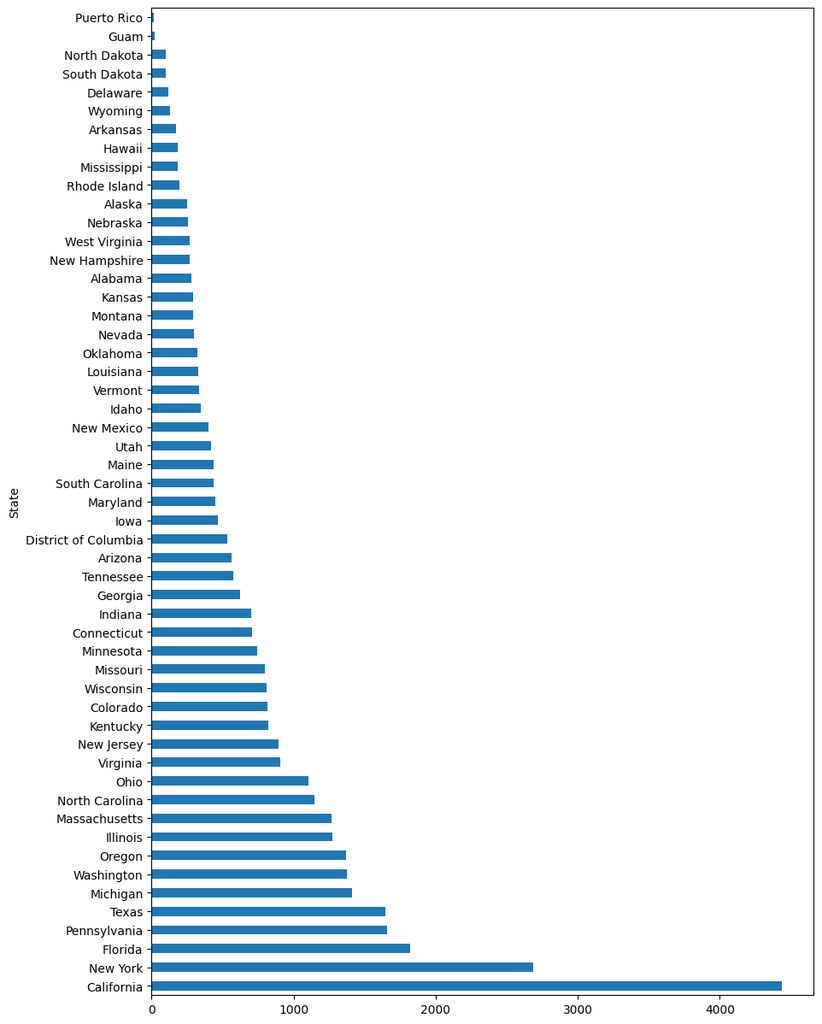

```python
protests_by_state = protests_temp.value_counts('State')
protests_by_state.plot.barh(figsize=(10,15))
```

From this bar chart, we can see that California has the highest number of protests. California also had the highest number of radicalized individuals.

```python
protests_by_state.mean()
```

```
718.7924528301887
```

We can also see that the mean number of protests by state is 718.

# Population Data

Source: Census Bureau. Notes: The years 2020 and 2021 were in different files, so had to join them.

```python
pop20_21 = pd.read_csv('./Population/2020-2021 Census Bureau Population.csv')
#Rename columns due to header reading error
pop20_21.rename(columns={'Population Estimate\n (as of July 1)':'2020','Unnamed: 3':'2021'},inplace=True)
#Drop the first 6 rows becausethey are aggregates
pop20_21 = pop20_21.iloc[6:]
list1 = []
for i in pop20_21['Geographic Area']:
  i = i[1:]
  list1.append(i)
pop20_21['Geographic Area'] = list1
pop20_21.head()
```

|  | Geographic Area | April 1, 2020 Estimates Base | 2020 | 2021 |
| --- | --- | --- | --- | --- |
| 6 | Alabama | 5024279.0 | 5024803.0 | 5039877.0 |
| 7 | Alaska | 733391.0 | 732441.0 | 732673.0 |
| 8 | Arizona | 7151502.0 | 7177986.0 | 7276316.0 |
| 9 | Arkansas | 3011524.0 | 3012232.0 | 3025891.0 |
| 10 | California | 39538223.0 | 39499738.0 | 39237836.0 |

```python
pop10_19 = pd.read_csv('./Population/nst-est2019-01.csv')
#Rename columns due to header reading error
pop10_19.rename(columns={'Population Estimate (as of July 1)':'2010','Unnamed: 2':'Estimates Base','Unnamed: 4':'2011','Unnamed: 5':'2012','Unnamed: 5':'2012','Unnamed: 6':'2013','Unnamed: 7':'2014','Unnamed: 8':'2015','Unnamed: 9':'2016','Unnamed: 10':'2017','Unnamed: 11':'2018','Unnamed: 12': '2019'},inplace=True)
#Drop the first 6 rows becausethey are aggregates
pop10_19 = pop10_19.iloc[6:]
list1 = []
for i in pop10_19['Geographic Area']:
  i = i[1:]
  list1.append(i)
pop10_19['Geographic Area'] = list1
pop10_19.head()
```

|  | Geographic Area | April 1, 2010 | Estimates Base | 2010 | 2011 | 2012 | 2013 | 2014 | 2015 | 2016 | 2017 | 2018 | 2019 |
| --- | --- | --- | --- | --- | --- | --- | --- | --- | --- | --- | --- | --- | --- |
| 6 | Alabama | 4779736.00 | 4780125.00 | 4785437.0 | 4799069.0 | 4815588.0 | 4830081.0 | 4841799.0 | 4852347.0 | 4863525.0 | 4874486.0 | 4887681.0 | 4903185.0 |
| 7 | Alaska | 710231.00 | 710249.00 | 713910.0 | 722128.0 | 730443.0 | 737068.0 | 736283.0 | 737498.0 | 741456.0 | 739700.0 | 735139.0 | 731545.0 |
| 8 | Arizona | 6392017.00 | 6392288.00 | 6407172.0 | 6472643.0 | 6554978.0 | 6632764.0 | 6730413.0 | 6829676.0 | 6941072.0 | 7044008.0 | 7158024.0 | 7278717.0 |
| 9 | Arkansas | 2915918.00 | 2916031.00 | 2921964.0 | 2940667.0 | 2952164.0 | 2959400.0 | 2967392.0 | 2978048.0 | 2989918.0 | 3001345.0 | 3009733.0 | 3017804.0 |
| 10 | California | 37253956.00 | 37254519.00 | 37319502.0 | 37638369.0 | 37948800.0 | 38260787.0 | 38596972.0 | 38918045.0 | 39167117.0 | 39358497.0 | 39461588.0 | 39512223.0 |

```python
total_population = pop10_19
total_population['2020'] = pop20_21['2020']
total_population['2021'] = pop20_21['2021']
total_population.drop(['April 1, 2010','Estimates Base'],inplace=True,axis=1)
```

```python
total_population.columns
```

```
Index(['Geographic Area', '2010', '2011', '2012', '2013', '2014', '2015',
       '2016', '2017', '2018', '2019', '2020', '2021'],
      dtype='object')
```

```python
def df_creation(row):
  ret_val = pd.DataFrame()
  ret_val['Population'] = list(row)[1:]
  ret_val['Year'] = total_population.columns[1:]
  return ret_val

S_pop = {}
for index, row in total_population.iterrows():
  S_pop[list(row)[0]] = df_creation(row)
```

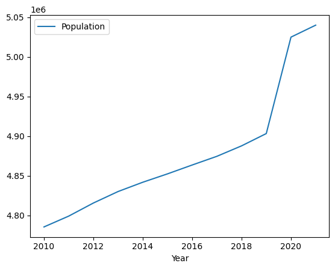

```python
ax=S_pop['Alabama'].plot(x='Year',y='Population')
```

```python
total_population
```

|  | Geographic Area | 2010 | 2011 | 2012 | 2013 | 2014 | 2015 | 2016 | 2017 | 2018 | 2019 | 2020 | 2021 |
| --- | --- | --- | --- | --- | --- | --- | --- | --- | --- | --- | --- | --- | --- |
| 6 | Alabama | 4785437.0 | 4799069.0 | 4815588.0 | 4830081.0 | 4841799.0 | 4852347.0 | 4863525.0 | 4874486.0 | 4887681.0 | 4903185.0 | 5024803.0 | 5039877.0 |
| 7 | Alaska | 713910.0 | 722128.0 | 730443.0 | 737068.0 | 736283.0 | 737498.0 | 741456.0 | 739700.0 | 735139.0 | 731545.0 | 732441.0 | 732673.0 |
| ... | ... | ... | ... | ... | ... | ... | ... | ... | ... | ... | ... | ... | ... |
| 55 | Wisconsin | 5690475.0 | 5705288.0 | 5719960.0 | 5736754.0 | 5751525.0 | 5760940.0 | 5772628.0 | 5790186.0 | 5807406.0 | 5822434.0 | 5892323.0 | 5895908.0 |
| 56 | Wyoming | 564487.0 | 567299.0 | 576305.0 | 582122.0 | 582531.0 | 585613.0 | 584215.0 | 578931.0 | 577601.0 | 578759.0 | 577267.0 | 578803.0 |

51 rows × 13 columns

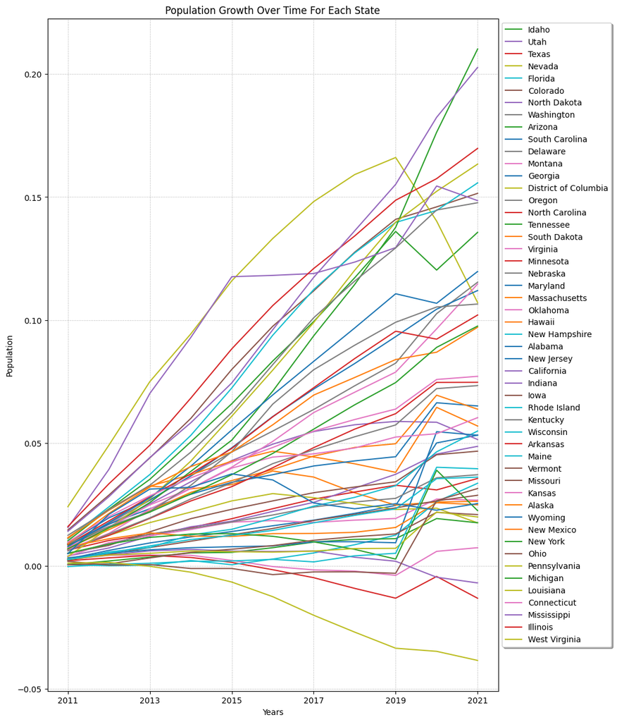

```python
per_population_growth = total_population.copy()
years = [2010,2011,2012,2013,2014,2015,2016,2017,2018,2019,2020,2021]
for i in range(len(years)):
    per_population_growth[str(years[len(years) - i - 1])] = total_population[str(years[len(years)- i- 1])]/total_population['2010']-1

per_population_growth.drop(['2010'],inplace=True,axis=1)
per_population_growth.set_index('Geographic Area').transpose().plot(figsize=(10,15))
plt.legend()
#plt.yscale("log")
plt.xlabel("Years")
plt.ylabel("Population")
plt.title("Population Growth Over Time For Each State")
plt.grid(linestyle=':')

handles, labels = plt.gca().get_legend_handles_labels()
order = per_population_growth['2021'].sort_values(ascending=False).keys()
order = order-6

plt.legend([handles[idx] for idx in order],[labels[idx] for idx in order],bbox_to_anchor=(1., 1.0), fancybox=True, shadow=True, ncol=1)
```

```python
pd.pivot_table(total_population, index='Geographic Area').head()
```

| Geographic Area | 2010 | 2011 | 2012 | 2013 | 2014 | 2015 | 2016 | 2017 | 2018 | 2019 | 2020 | 2021 |
| --- | --- | --- | --- | --- | --- | --- | --- | --- | --- | --- | --- | --- |
| Alabama | 4785437.0 | 4799069.0 | 4815588.0 | 4830081.0 | 4841799.0 | 4852347.0 | 4863525.0 | 4874486.0 | 4887681.0 | 4903185.0 | 5024803.0 | 5039877.0 |
| Alaska | 713910.0 | 722128.0 | 730443.0 | 737068.0 | 736283.0 | 737498.0 | 741456.0 | 739700.0 | 735139.0 | 731545.0 | 732441.0 | 732673.0 |
| Arizona | 6407172.0 | 6472643.0 | 6554978.0 | 6632764.0 | 6730413.0 | 6829676.0 | 6941072.0 | 7044008.0 | 7158024.0 | 7278717.0 | 7177986.0 | 7276316.0 |
| Arkansas | 2921964.0 | 2940667.0 | 2952164.0 | 2959400.0 | 2967392.0 | 2978048.0 | 2989918.0 | 3001345.0 | 3009733.0 | 3017804.0 | 3012232.0 | 3025891.0 |
| California | 37319502.0 | 37638369.0 | 37948800.0 | 38260787.0 | 38596972.0 | 38918045.0 | 39167117.0 | 39358497.0 | 39461588.0 | 39512223.0 | 39499738.0 | 39237836.0 |

# Merging Data

Both protest and radicalization measure resistance to social or governmental structures. Therefore, it makes sense to join aspects of the data into a very simple table to compare radicalization and protest activity. We will not merge this data on the 'State' attribute, because both datasets have such a large number of variables that the table produced would be unweildy.

```python
resistance_data = pd.DataFrame()
resistance_data['Radicalized_num'] = pirus_states_since_2000
resistance_data['Protest_num'] = protests_by_state
resistance_data.head()
```

| Loc_Habitation_State1 | Radicalized_num | Protest_num |
| --- | --- | --- |
| California | 137 | 4439.0 |
| New York | 108 | 2688.0 |
| Texas | 84 | 1649.0 |
| Florida | 83 | 1823.0 |
| Minnesota | 70 | 747.0 |

We can look at the relationship now between the number of protests in a state and the number of radicalized individuals in a state. Unsurprisingly, there is a visually obvious correlation.

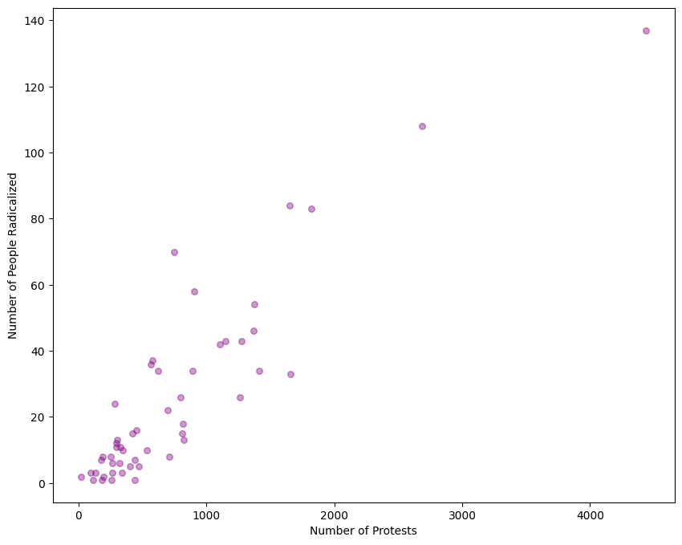

```python
resistance_data.rename({'Loc_Habitation_State1':'State'},inplace=True)
resistance_data.plot(kind='scatter',
                     y='Radicalized_num',
                     x='Protest_num',
                     ylabel = "Number of People Radicalized",
                     xlabel = "Number of Protests",
                     figsize=(10,8),
                     alpha=0.4,
                     color='purple',
                     s=30)
```

We can compute the correlation between these two variables as follows:

```python
resistance_data['Protest_num'].corr(resistance_data['Radicalized_num'])
```

```
0.8996117793328046
```

This is a significant, but unsurprising correlation. We can represent the population size of the state through the dot size.

```python
resistance_data_merged = resistance_data.reset_index().rename(columns={'Loc_Habitation_State1':'State'}).merge(total_population.rename(columns={'Geographic Area':'State',"2021":"Population"})[["State","Population"]],on='State', how="right").set_index("State")
resistance_data_merged.head()
```

| State | Radicalized_num | Protest_num | Population |
| --- | --- | --- | --- |
| Alabama | 24.0 | 281.0 | 5039877.0 |
| Alaska | 8.0 | 252.0 | 732673.0 |
| Arizona | 36.0 | 563.0 | 7276316.0 |
| Arkansas | 7.0 | 174.0 | 3025891.0 |
| California | 137.0 | 4439.0 | 39237836.0 |

```python
resistance_data_merged["Population"]
```

```
State
Alabama      5039877.0
Alaska        732673.0
               ...
Wisconsin    5895908.0
Wyoming       578803.0
Name: Population, Length: 51, dtype: float64
```

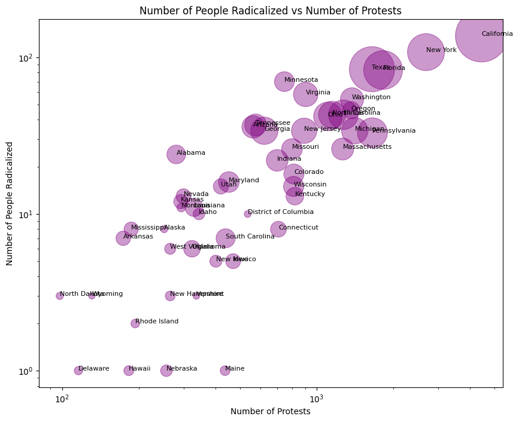

```python
resistance_data_merged.plot(kind='scatter',
                     y='Radicalized_num',
                     x='Protest_num',
                     ylabel = "Number of People Radicalized",
                     xlabel = "Number of Protests",
                     title="Number of People Radicalized vs Number of Protests",
                     figsize=(10,8),
                     alpha=0.4,
                     color='purple',
                     #s = resistance_data_merged['Population']
                     s=resistance_data_merged["Population"].apply({lambda x: x/1e4}),
                     )
plt.xscale("log")
plt.yscale("log")
x_vals = list(resistance_data_merged.reset_index()["Protest_num"])
y_vals = list(resistance_data_merged.reset_index()["Radicalized_num"])
states = list(resistance_data_merged.reset_index()["State"])
x_vals.pop(41)
y_vals.pop(41)
states.pop(41) # South Dakota has nan values
for i in range(len(x_vals)):
    plt.text(x_vals[i], y_vals[i], states[i], fontsize=8)
```

### Protests and Radicalized Individuals Based On State

One flaw with the graph above using the population value was that it essentially meant nothing. When comparing large sets of data belonging to different areas, it's important to normalize them by some factor, so that the data is proportional. After normalizing the data, a very interesting but telling picture shows. Therefore, it is unsurprising to see the largest states have both the most radicalized individuals as well as protests, so a better perspective would be to normalize each of those values based on population. Below will give a better view on each state's participation in politics

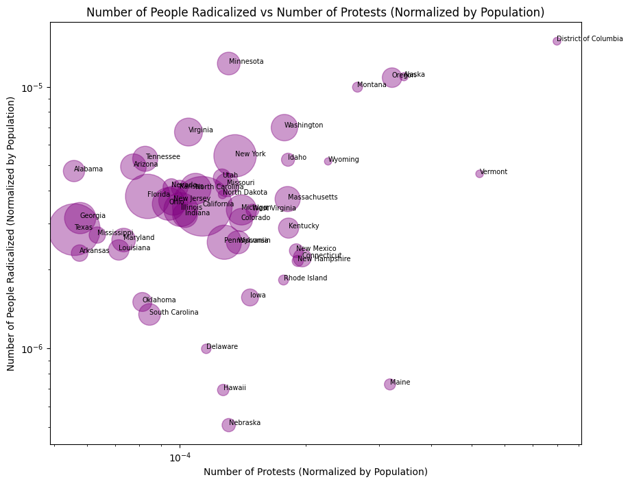

```python
resistance_data_normalized = resistance_data_merged.copy()
resistance_data_normalized["Protest_num"] = resistance_data_normalized["Protest_num"]/resistance_data_normalized["Population"]
resistance_data_normalized["Radicalized_num"] = resistance_data_normalized["Radicalized_num"]/resistance_data_normalized["Population"]
resistance_data_normalized.plot(kind='scatter',
                     y='Radicalized_num',
                     x='Protest_num',
                     ylabel = "Number of People Radicalized (Normalized by Population)",
                     xlabel = "Number of Protests (Normalized by Population)",
                     title="Number of People Radicalized vs Number of Protests (Normalized by Population)",
                     figsize=(10,8),
                     alpha=0.4,
                     color='purple',
                     #s = resistance_data_merged['Population']
                     s=resistance_data_normalized["Population"].apply({lambda x: x/1e4}))
plt.xscale("log")
plt.yscale("log")
x_vals = list(resistance_data_normalized.reset_index()["Protest_num"])
y_vals = list(resistance_data_normalized.reset_index()["Radicalized_num"])
x_vals.pop(41)
y_vals.pop(41)
for i in range(len(x_vals)):
    plt.text(x=x_vals[i], y=y_vals[i], s=states[i], fontsize=7)
```

### Normalized Protests and Radicalized Individuals

DC is in the top right, making it the most participatory "state" in the United States. This makes sense because it's home to the White House, and many protests likely occur here by others outside of DC. The number of protests in proportion to its population as just a city make it key for political involvement. This conclusion can mostly be drawn from the fact that in the graph using just the population values, DC is pretty central in the graph, meaning that it can stand on its own without being normalized.

# Models

### Model 1: Preface

The Protest data Attendance column is missing values for many events. We will build a model to predict what the attendance would have been based on the issues the protest addressed, the state protest took place in, and the proportion of the radicalized individuals from that state.

First, let's look at what issues people protest about most often.

```python
protests_iss =protests_temp[['Date','Location','Event (legacy; see tags)', 'Attendees','State','Tags']]
protests_iss_known = protests_iss
```

```python
protests_iss_known.rename(columns={'Event (legacy; see tags)':'Event'},inplace=True)
```

### Tagging System

The person who gathered this protest data did not report the political/social topics of the protest consistently. We will create a new tagging system using regular expressions to search the current tagging system for the most common issues present. This tagging system will build a set of issues that can be searched.

```python
def categorizer(word):
    p_list = [r"\s*([Rr]acial)",
    r'\s*(45)', r"\s*([Gg]un\s[Rr]ights)",r"\s*([Gg]un\s[Cc]ontrol)",
     r"\s*([Oo]ther)", r"\s*([Ee]nvironment)",
     r"\s*([Ee]ducation)",r'\s*([Hh]ealthcare)',
     r"\s*([Ii]mmigration)",r"\s*([Ee]xecutive)",
     r"\s*([Ii]nternational\s[Rr]elations)",
     r"\s*([Ll]egislative)",r"\s*([Cc]ivil\s[Rr]ights)"]
    tag_dict = {r"\s*([Rr]acial)":"Racial",
    r'\s*(45)':"45th President", r"\s*([Gg]un\s[Rr]ights)":"Gun Rights",r"\s*([Gg]un\s[Cc]ontrol)":"Gun Control",
     r"\s*([Oo]ther)":'Other', r"\s*([Ee]nvironment)":'Environment',
     r"\s*([Ee]ducation)":"Education",r'\s*([Hh]ealthcare)':'Healthcare',
     r"\s*([Ii]mmigration)":'Immigration',r"\s*([Ee]xecutive)":'Executive',
     r"\s*([Ii]nternational\s[Rr]elations)":'International Relations',
     r"\s*([Ll]egislative)":'Legislative',r"\s*([Cc]ivil\s[Rr]ights)":'Civil Rights','[]':'Other'}
    ret_list = set([])
    for w in word.split(';'):
        #print(w)
        for pattern in p_list:
            m = re.search(pattern,w)
            if m != None:
                b = tag_dict[pattern]
                if b not in ret_list:
                    ret_list.add(b)
    return ret_list
```

```python
events = []
for a in protests_iss_known["Tags"]:
    events.append(categorizer(a))
#eventsssss = protests_iss_known["Tags"].apply({lambda x: categorizer(x)}) # "Racial Injustice" if "Racial Injustice" in x else "Gun Rights" if "Guns" in x else "Other" if "Other" in x else "Environment" if "Environment" in x else "Education" if "Education" in x else "Immigration" if "Immigration" in x else x
protests_iss_known["Event"] = events
Common_Events = protests_iss_known["Event"].value_counts().head(12).keys()
#print(len(protests_iss_known["Event"].value_counts()))
#protests_iss_known["Event"] = protests_iss_known["Event"].apply({lambda x: x if x in Common_Events else "Other"})
```

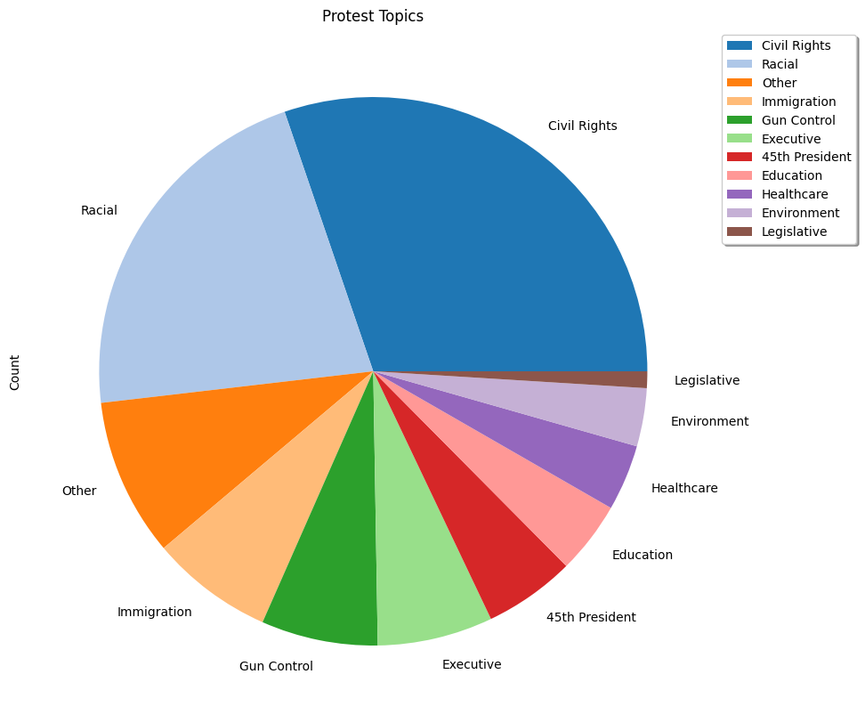

```python
def overlapping_value_count(df,return_dict):
    s = df['Event']
    for entry in s:
        l = list(entry)
        for e in l:
            if e in return_dict.keys():
                return_dict[e] += 1
            else:
                return_dict[e] = 1
    ret_val = pd.DataFrame(list(return_dict.items()),index=range(0,len(return_dict.keys())))
    ret_val.columns = ['Tag','Count']
    ret_val.set_index('Tag',inplace=True)
    return ret_val
tag_counts = overlapping_value_count(protests_iss_known,{})
tag_counts.sort_values("Count", ascending=False).plot(y='Count',kind='pie',figsize=(10,10),fontsize=10,legend=True,title='Protest Topics',colors=sns.color_palette('tab20'))
plt.legend(bbox_to_anchor=(1., 1.0), fancybox=True, shadow=True, ncol=1)
```

Notice that this graph does not show the distribution of topics across all events, but across all tags, as each event may have multiple tags in its list.

Just from looking at this chart, it looks like civil rights, racial justice, guns, and immigration are major issues that people protest about..

```python
protests_iss_known.Date = pd.to_datetime(protests_iss_known.Date)
protests_real_test = protests_iss.query('Attendees != Attendees')
protests_iss_attendees_known = protests_iss.dropna(subset=['Attendees'])
```

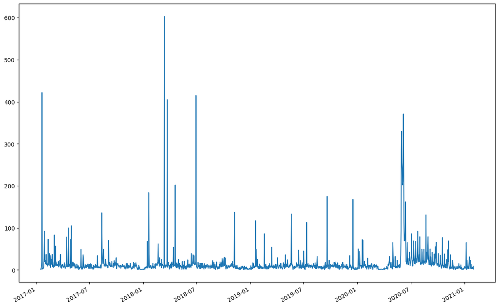

```python
protests_iss_attendees_known.Date.value_counts().plot(figsize=(15,10))
```

```python
protests_real_test
```

|  | Date | Location | Event | Attendees | State | Tags |
| --- | --- | --- | --- | --- | --- | --- |
| 2 | 2017-01-16 | Cincinnati, OH | {Racial, Civil Rights} | NaN | Ohio | Civil Rights; For racial justice; Martin Luthe... |
| 4 | 2017-01-19 | Washington, DC | {45th President, Executive} | NaN | District of Columbia | Executive; Against 45th president |
| ... | ... | ... | ... | ... | ... | ... |
| 38092 | 2021-01-31 | Topeka, KS | {Civil Rights} | NaN | Kansas | Civil Rights; For abortion rights |
| 38094 | 2021-01-31 | Salt Lake City, UT | {Other} | NaN | Utah | Other; Against deregulation; Business |

15061 rows × 6 columns